# Predicting Adverse Event Risk in a CDISC Clinical Trial Pipeline

CDISC Pilot Study, Xanomeline vs Placebo

Jeremy Barton

2026-02-19

# Introduction and Overview

This pipeline demonstrates a complete ADaM data workflow built using the pharmaverse R ecosystem, the open-source initiative co-maintained by Roche, GSK, Pfizer, and other major pharmaceutical companies to standardize clinical programming in R. Source data is drawn from the CDISC pilot SDTM dataset, which represents a Phase III clinical trial comparing Xanomeline (low and high dose) against Placebo in Alzheimer’s disease patients.

The pipeline follows the same standards used in FDA regulatory submissions: CDISC SDTM as input, ADaM datasets as analysis-ready output, TLFs (Tables, Listings, Figures) as the deliverables, and a downstream predictive model demonstrating how structured clinical data feeds into ML-driven patient stratification.

# Data Sources

All source data comes from the `pharmaversesdtm` R package, which contains CDISC-compliant SDTM test datasets maintained by the pharmaverse community.

| Domain | Description | Granularity |
| --- | --- | --- |
| DM | Demographics | One row per patient |
| EX | Exposure (dosing records) | Many per patient |
| AE | Adverse Events | Many per patient |
| DS | Disposition | One row per patient |

# ADaM Datasets

## ADSL: Subject Level Analysis Dataset

ADSL is the foundation of every ADaM package. It contains exactly one row per patient and captures baseline characteristics, treatment assignment, and population flags. Every downstream dataset joins back to ADSL using `USUBJID` as the key.

### Population Summary

Safety Population by Treatment Arm

| Treatment Arm | N |
| --- | --- |
| Placebo | 86 |
| Xanomeline High Dose | 84 |
| Xanomeline Low Dose | 84 |

The trial enrolled 306 patients, of whom 254 formed the safety population. The remaining 52 patients were screen failures and are excluded from all downstream analyses.

### Baseline Demographics

Baseline Demographics, Safety Population

| Treatment Arm | N | Mean Age | SD Age | Median Age | % Female |
| --- | --- | --- | --- | --- | --- |
| Placebo | 86 | 75.2 | 8.6 | 76.0 | 61.6 |
| Xanomeline High Dose | 84 | 74.4 | 7.9 | 76.0 | 47.6 |
| Xanomeline Low Dose | 84 | 75.7 | 8.3 | 77.5 | 59.5 |

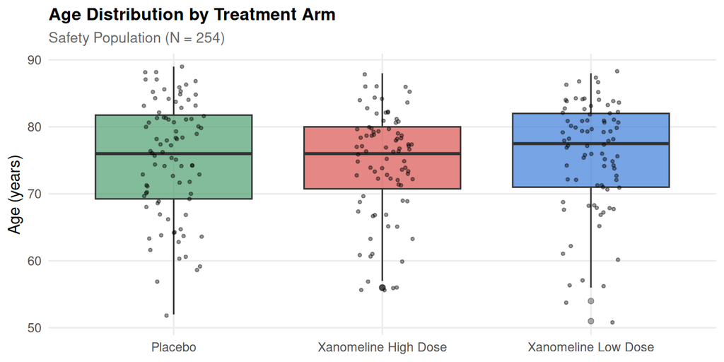

The three arms are well balanced on age, with mean ages ranging from 74.4 to 75.7 years and overlapping distributions visible in the boxplot above. Sex distribution shows a notable imbalance, however: the Xanomeline High Dose arm enrolled 47.6% female versus 61.6% in Placebo and 59.5% in Low Dose. This warrants attention in any subsequent analysis comparing arms, since sex can confound tolerability comparisons.

## ADAE: Adverse Event Profile by Treatment Arm

The treatment-emergent flag (`TRTEMFL`) was derived per FDA guidance, distinguishing drug-related signals from pre-treatment conditions. This forms the basis for safety surveillance and patient stratification across treatment arms.

### Treatment-Emergent AE Overview

Treatment-Emergent Adverse Events by Arm

| Treatment Arm | Events | Patients | Events/Patient | % Serious |
| --- | --- | --- | --- | --- |
| Placebo | 281 | 65 | 4.32 | 0.0 |
| Xanomeline High Dose | 427 | 76 | 5.62 | 0.5 |
| Xanomeline Low Dose | 412 | 77 | 5.35 | 0.2 |

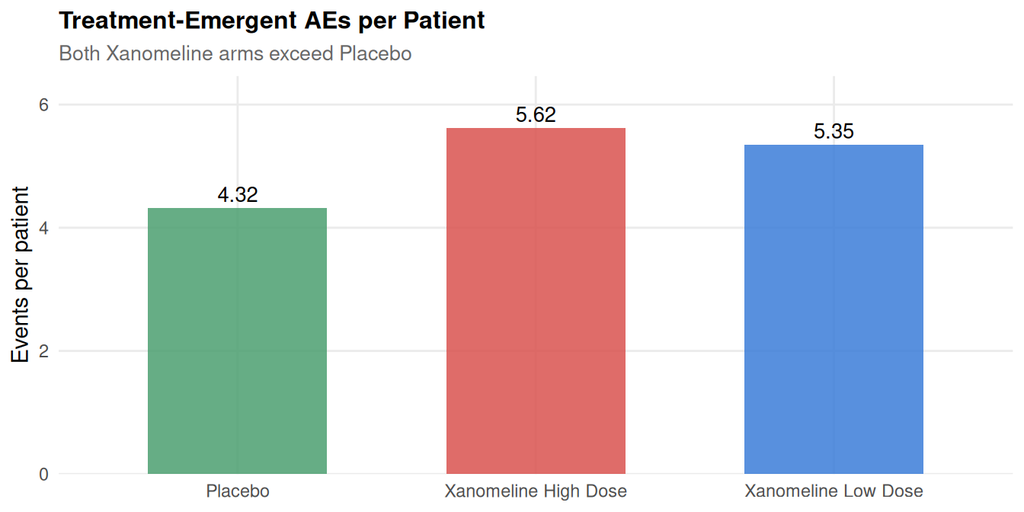

Both Xanomeline arms produced more events per patient than Placebo: 1.3x for High Dose (5.62 vs. 4.32 events/patient) and 1.24x for Low Dose (5.35 vs. 4.32). Serious AEs were rare across all arms (no greater than 0.5%), suggesting the differential signal is driven by frequency of nuisance events rather than severity.

### Top System Organ Classes by Arm

Top 10 System Organ Classes (TEAEs)

| System Organ Class | Plac | Xan High | Xan Low | Total |
| --- | --- | --- | --- | --- |
| GENERAL DISORDERS AND ADMINISTRATION SITE CONDITIONS | 46 | 123 | 118 | 287 |
| SKIN AND SUBCUTANEOUS TISSUE DISORDERS | 45 | 104 | 111 | 260 |
| NERVOUS SYSTEM DISORDERS | 11 | 39 | 40 | 90 |
| CARDIAC DISORDERS | 26 | 30 | 30 | 86 |
| GASTROINTESTINAL DISORDERS | 26 | 36 | 22 | 84 |
| INFECTIONS AND INFESTATIONS | 35 | 19 | 16 | 70 |
| RESPIRATORY, THORACIC AND MEDIASTINAL DISORDERS | 12 | 22 | 14 | 48 |
| PSYCHIATRIC DISORDERS | 12 | 11 | 14 | 37 |
| INVESTIGATIONS | 19 | 8 | 7 | 34 |
| INJURY, POISONING AND PROCEDURAL COMPLICATIONS | 9 | 8 | 12 | 29 |

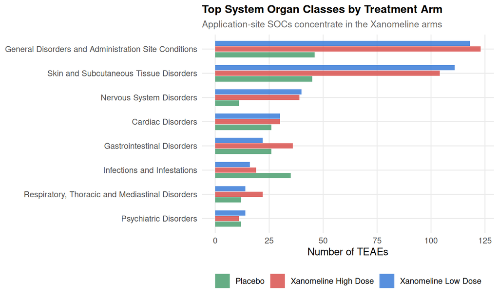

## ADTTE: Time to Treatment Discontinuation

Kaplan-Meier analysis of time-to-discontinuation reveals differential tolerability across dose arms, directly informing dose selection and risk-benefit assessment.

### Kaplan-Meier Survival Curve

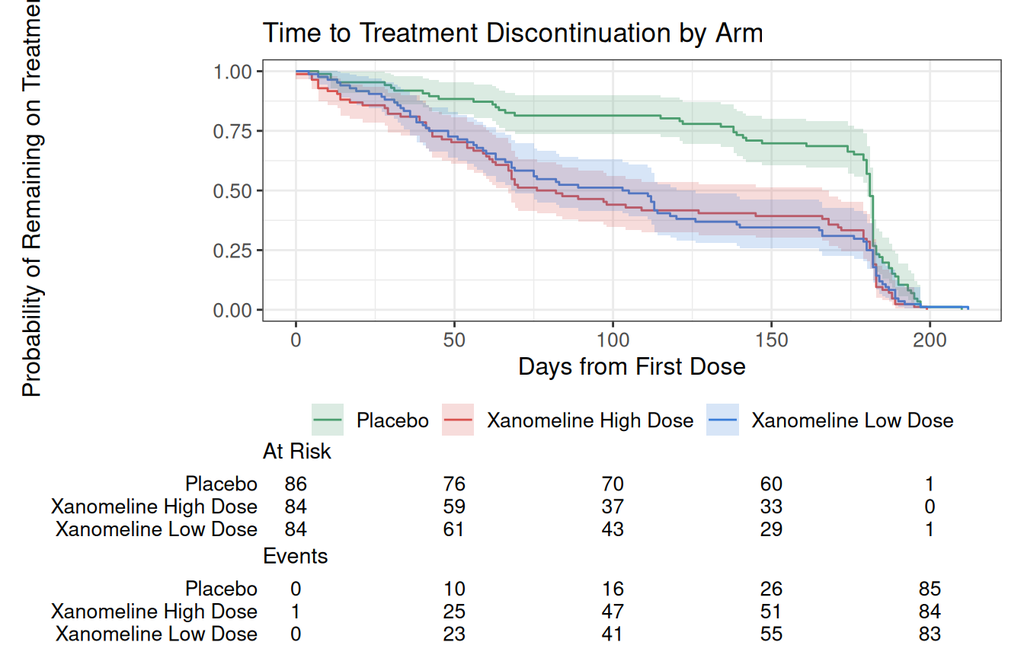

### Log-Rank Test and Median Time-to-Event

Time to Discontinuation Summary

| Treatment Arm | N | Events | Median Days |
| --- | --- | --- | --- |
| Placebo | 86 | 86 | 181 |
| Xanomeline High Dose | 84 | 84 | 79 |
| Xanomeline Low Dose | 84 | 84 | 104 |

# Predictive Modeling: Baseline Risk Stratification

Patient stratification is the central goal of this section. Two complementary models are fit: a *baseline-only* risk model, using only pre-treatment characteristics (AGE, SEX), and a *full* model that adds treatment arm. Keeping them separate matters because mixing them would conflate intrinsic patient risk with the trial’s treatment effect; the baseline model captures who is at risk before any drug is given, while the full model layers on what the drug itself contributes.

The modeling cohort comprises **254 patients** in the safety population. The overall TEAE incidence is **85.8%**, an unusually high event rate that has implications for model performance discussed below.

## Stratification Overview

Before walking through the modeling math, the chart below shows what stratification looks like in this cohort: every patient is plotted by their full-model predicted risk, sorted from lowest to highest, colored by treatment arm, and bucketed into Low/Medium/High tertiles. This is the visual the entire predictive section is building toward: a defensible way to sort patients by adverse event likelihood.

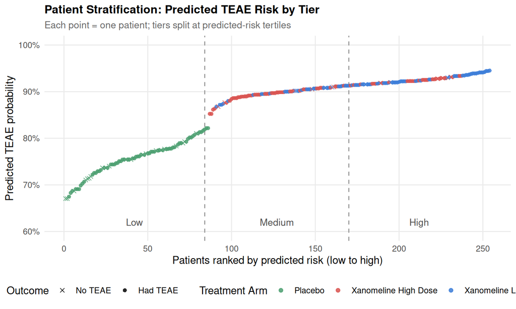

The structure here makes the dominant signal visible: Placebo patients (green) cluster in the Low tier, Xanomeline patients (blue and red) dominate Medium and High. Filled circles mark patients who actually had a TEAE; their density visibly increases left-to-right, which is what calibration is supposed to look like.

## Model 1: Baseline-Only Risk

Baseline-Only Risk Factors (Odds Ratios)

| term | estimate | std.error | statistic | p.value | conf.low | conf.high |
| --- | --- | --- | --- | --- | --- | --- |
| (Intercept) | 1.387 | 1.612 | 0.203 | 0.8391 | 0.064 | 36.837 |
| AGE | 1.018 | 0.021 | 0.826 | 0.4089 | 0.975 | 1.061 |
| SEXM | 1.480 | 0.374 | 1.047 | 0.2953 | 0.720 | 3.159 |

**Baseline-only AUC: 0.569.** Age and sex alone show essentially no signal for predicting TEAEs, consistent with the absence of strong univariate trends in this cohort. This is the appropriate “intrinsic patient risk” baseline before treatment is considered.

## Model 2: Full Model with Treatment Arm

Full Model Including Treatment Arm (Odds Ratios)

| term | estimate | std.error | statistic | p.value | conf.low | conf.high |
| --- | --- | --- | --- | --- | --- | --- |
| (Intercept) | 0.676 | 1.657 | −0.236 | 0.8131 | 0.028 | 19.262 |
| AGE | 1.019 | 0.022 | 0.862 | 0.3889 | 0.976 | 1.063 |
| SEXM | 1.393 | 0.385 | 0.860 | 0.3896 | 0.662 | 3.033 |
| ARMXanomeline High Dose | 3.001 | 0.452 | 2.430 | 0.0151 | 1.278 | 7.677 |
| ARMXanomeline Low Dose | 3.534 | 0.469 | 2.692 | 0.0071 | 1.470 | 9.476 |

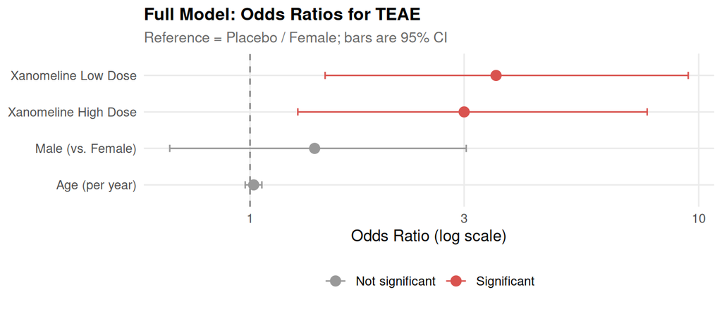

Treatment arm dominates the full model. Both Xanomeline arms carry significantly elevated TEAE odds vs. Placebo (Low Dose OR = 3.53, p = 0.0071; High Dose OR = 3, p = 0.015), while age and sex remain non-significant. The full-model AUC of **0.659** indicates modest discrimination: informative for population-level stratification but insufficient for confident individual-patient prediction.

## Calibration Across Risk Tiers

Stratifying patients into low, medium, and high risk tertiles (based on the full-model predictions) and comparing predicted to observed AE rates demonstrates **calibration**, a critical property for any clinical decision-support model.

Calibration: Observed AE Rate by Predicted Risk Tier

| Risk Tier | N | Mean Predicted Probability | Observed AE Rate |
| --- | --- | --- | --- |
| Low | 84 | 0.754 | 0.750 |
| Medium | 86 | 0.894 | 0.907 |
| High | 84 | 0.926 | 0.917 |

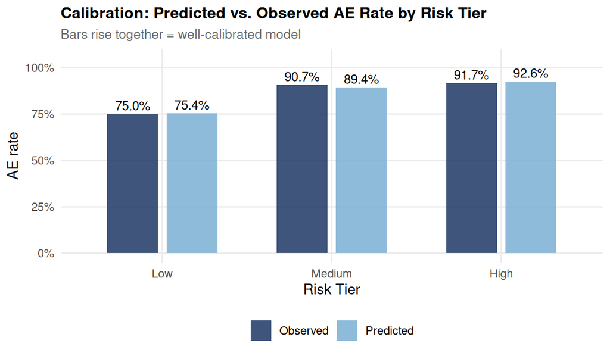

Observed AE rates rise monotonically with predicted risk tier (75.0%, 90.7%, 91.7%), confirming the model is well-calibrated even though discriminative power is modest. This is the property that matters for decision support: a patient flagged “High risk” really does have a higher AE rate than one flagged “Low.”

# Limitations and Next Iteration

A rigorous report names the limits of its own analysis. Three are worth surfacing here.

**Outcome saturation.** With a 85.8% TEAE rate in the safety population, the binary “any TEAE” outcome is near-saturated, leaving little signal for discrimination. This explains why even a treatment-effect-laden model achieves only AUC 0.659. Three reformulations would extract more signal from the same data: (1) count of TEAEs per patient, modeled with negative binomial regression; (2) time to first TEAE, modeled with a Cox proportional hazards model; or (3) severe-only TEAEs as the binary outcome to focus on clinically meaningful events.

**Limited baseline feature set.** ADSL provides only AGE, SEX, and a small number of derived flags. In a real translational setting, the baseline-only model would be enriched with laboratory values (LB), prior medical history (MH), concomitant medications (CM), and biomarker measurements. The current AUC of 0.569 for AGE plus SEX is a floor, not a ceiling.

**No held-out validation.** All performance metrics are in-sample. A rigorous evaluation would split the cohort into training and validation sets, or use k-fold cross-validation, before reporting AUC and calibration.

# Summary